# Foveal area of BrainWeb phantom’s primary visual cortex

W. Bauer

May 28, 2015

The point of this note is to identify the foveal area of the BrainWeb phantom’s left primary visual cortex and to extract a small volume around it for later study. The figure below is of a coronal section near the back of the phantom’s skull (y=80.) The broken line shows that the hemispheres divide at x=185. The left primary visual cortex will thus involve volumes for which x < 185.

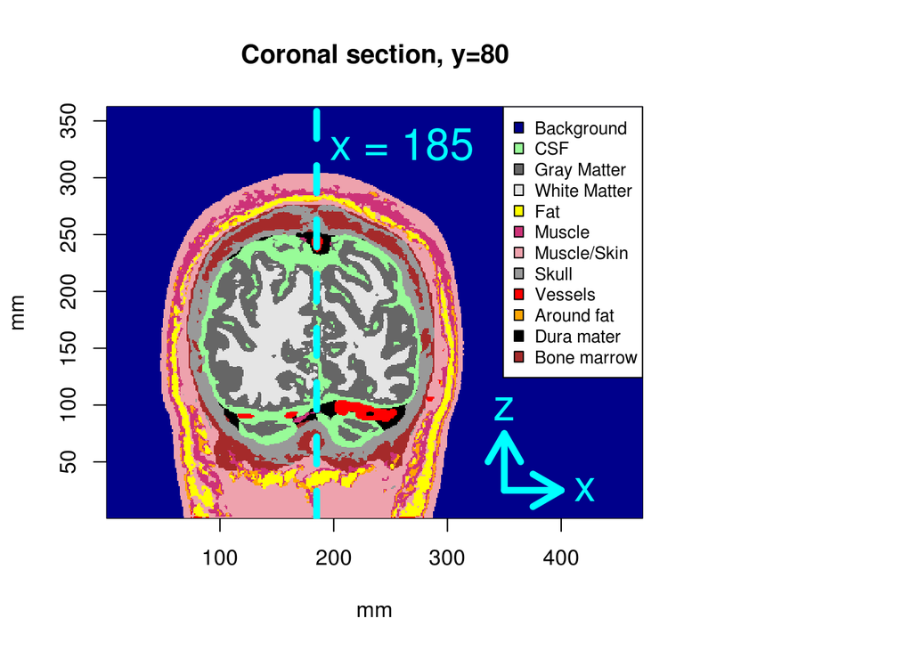

The next figure shows as sagittal section at x=175 which is far enough into the left hemisphere to show gray matter in some anatomical detail. What I believe to be the foveal area of the primary visual cortex is circled (generously; the area is probably smaller.)

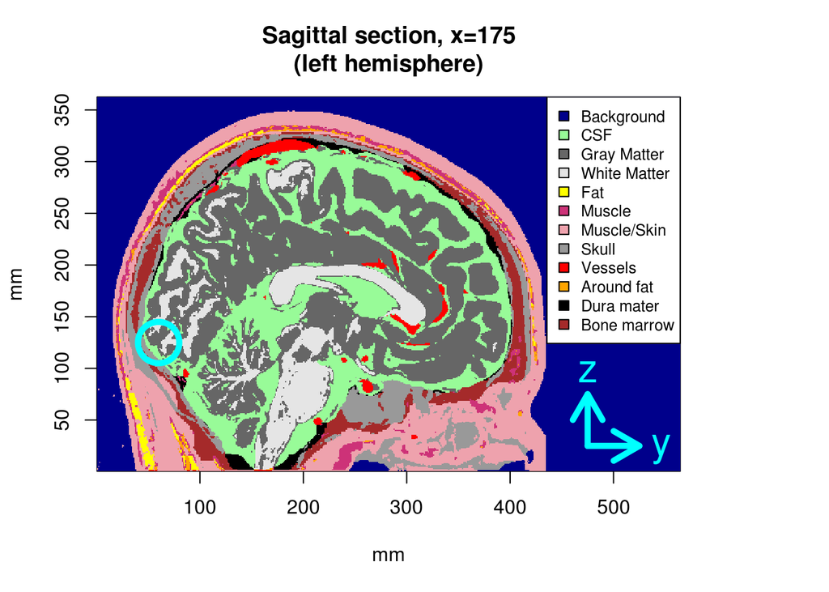

The pictured circle is centered at y=60 mm, z=125 mm, has a 20 mm radius. A column with $x = 165 \pm 19$, $z=125\pm 19$, and extending in the y direction from the skull to y=80 should include the area of interest. As it turns out, y=11 to 80 will include all the tissue.

```r
v1 <- phantom[(165-19):(165+19), 11:80, (125-19):(125+19)]
```

A series of sagittal sections of this volume are shown below.

```r
for(x in seq(39,1, by=-6)){
  v1a <- as.integer(v1[x,,]);dim(v1a)<-c(70,39);disp_slice(v1a, main=paste("x = ", x+165-19))
}
```

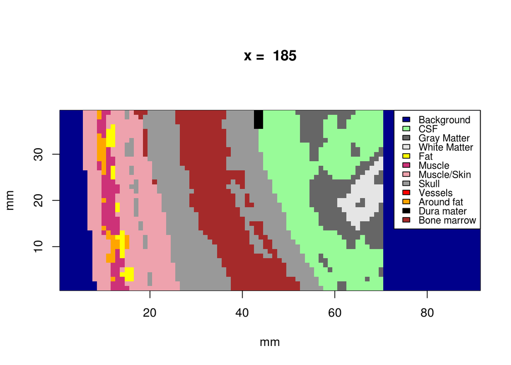

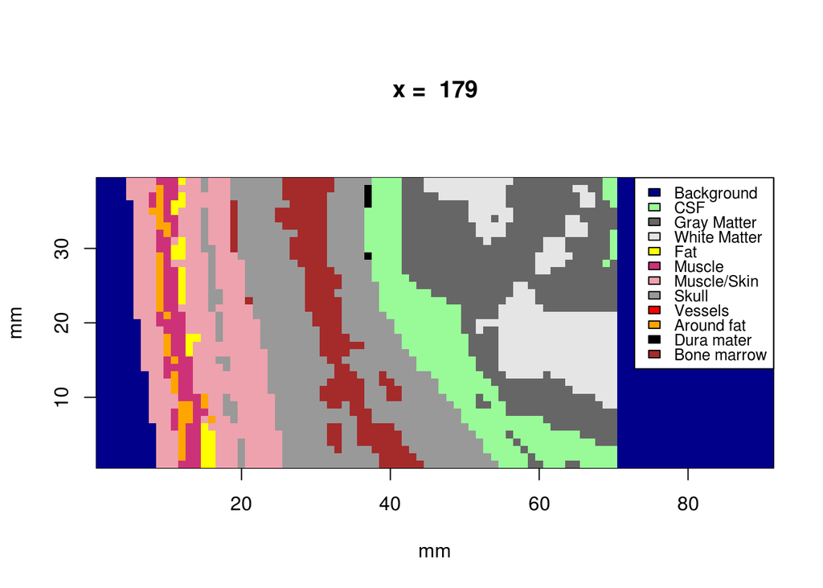

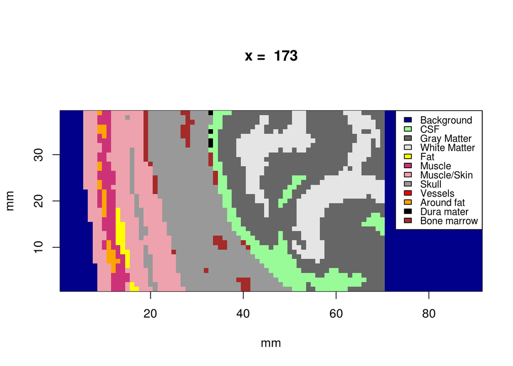

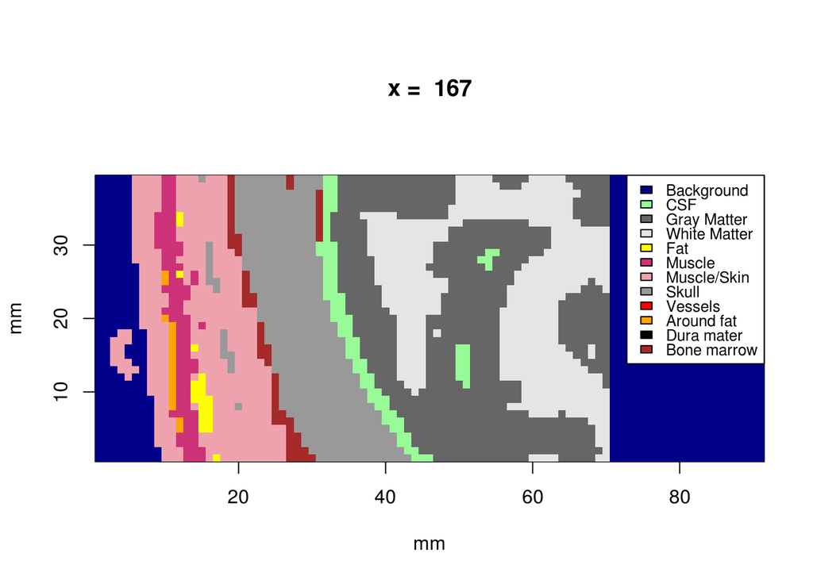

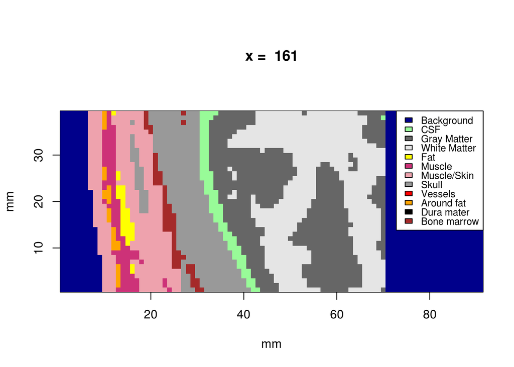

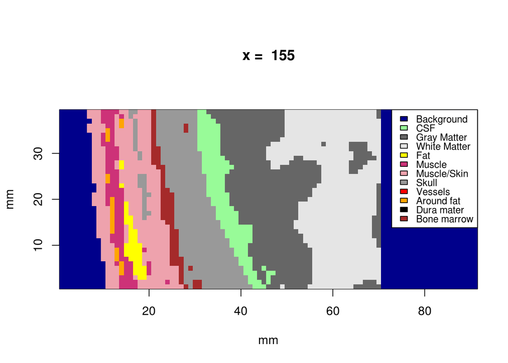

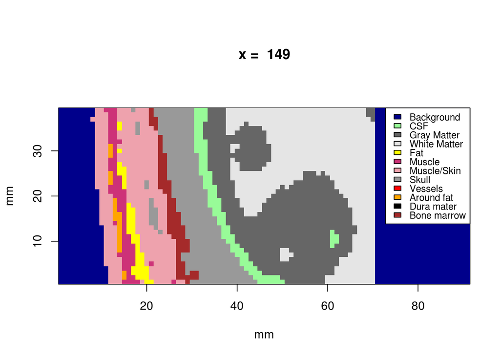